# Visualizing comorbidities and predicting readmission after surgery

Mustafa S Ascha

August 2, 2017

# 1 Motivation and Goals

- Predicting 30-day readmission on the basis of surgery/procedure characteristics
- Visualizing disease-disease networks
- Successfully identifying those diagnoses and procedures that can be targeted for quality improvement

# 2 What we have

- [Medicare data representing inpatient claims at the national level.](https://www.hcup-us.ahrq.gov/nisoverview.jsp)
- About 350,000 records of inpatient visits paid by Medicare
- 5 to 10 diagnoses per inpatient record
- Demographic data such as age, race, income quartile of patient zip code
- You can learn more about Medicare data [here](http://www.resdac.org/cms-data)
- American College of Surgeons’ National Surgical Quality Improvement Program (NSQIP)
- High-fidelity data, ACS NSQIP identifies more 30-day outcomes than do other quality programs
- Considers 30-day complications, which form the basis for Affordable Care Act reimbursement

# 3 Disease-length of stay relationships

- Size of node represents frequency of the diagnosis among all diagnoses
- Thickness of the edge connecting two nodes represents ‘lift’, which is how much more often we see the pair than we would expect if they occurred independently
- Selected relationships based on co-incidence metrics
- Black represents about 1 day spent at the hospital, whereas increasingly brighter shades represent greater length of stay.

[interactive chart not shown]

# 4 Procedure-return relationships

- Size of node represents frequency of the diagnosis among all diagnoses
- Thickness of the edge connecting two nodes represents ‘lift’, which is how much more often we see the pair than we would expect if they occurred independently
- Selected relationships based on co-incidence metrics
- Shades represent procedure-specific probability of unplanned readmission to the hospital after a procedure. Black represents probability of 1 that the patient will have an unplanned readmission to the hospital, whereas increasingly brighter shades represent lower probability of unplanned readmission.

[interactive chart not shown]

# 5 Recursive partitioning

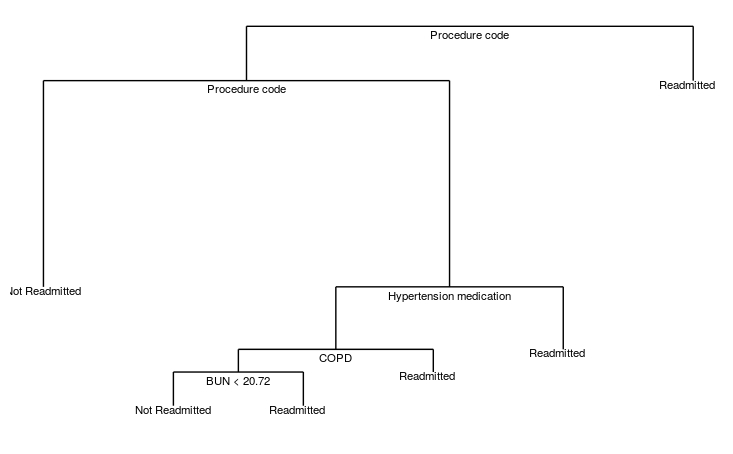

## 5.1 Recursive partition performance

Confusion Matrix and Statistics

| Reference |  |  |
| --- | --- | --- |
| Prediction | No Return | Returned |
| No Return | 13913 | 5509 |
| Returned | 8916 | 10760 |

| Metrics |  |
| --- | --- |
| Accuracy | 0.6311 |
| 95% CI | (0.6263, 0.6358) |

# 6 Random Forests

## 6.1 Performance

Confusion Matrix and Statistics

| Reference |  |  |
| --- | --- | --- |
| Prediction | No Return | Returned |
| No Return | 3499 | 1416 |
| Returned | 2213 | 2647 |

| Metrics |  |
| --- | --- |
| Accuracy | 0.6287 |
| 95% CI | (0.6191, 0.6383) |

# 7 End

Thanks!